# Adult Income Analysis

Kevin E. D’Elia

October 2nd, 2016

# Executive Summary

The purpose of this analysis is to predict whether income exceeds $50K/yr based on census data. Also known as “Census Income” dataset.

# Pre-requisites/Assumptions

Before working with this dataset, it is assumed that the following pre-requisites are met:

1. The dataset **adult.data.csv** has been loaded
2. The fields are comma-separated and there is no header
3. Variable names must be taken from the data dictionary and applied to the data

# Exploring and understanding data

```r
adultData <- read.table("./Adult/adult.data", sep = ",", header = FALSE)
names(adultData) <- c("age", "workclass", "fnlwgt", "education", "education_num", "marital_status", "occupation", "relationship", "race", "sex", "capital_gain", "capital_loss", "hours_per_week", "native_country", "income_level")
dim(adultData)
```

```
## [1] 32561    15
```

Now read in the test data, ignoring the first row (skip = 1) as it is garbage data, and remove the last column (“income_level”), since that is the column we are trying to predict:

```r
adultTest <- read.table("./Adult/adult.test", sep = ",", header = FALSE, skip = 1)
names(adultTest) <- c("age", "workclass", "fnlwgt", "education", "education_num", "marital_status", "occupation", "relationship", "race", "sex", "capital_gain", "capital_loss", "hours_per_week", "native_country", "income_level")
adultTest <- adultTest[, -15]
dim(adultTest)
```

```
## [1] 16281    14
```

## Exploring the structure of data

The data dictionary informs us that both datasets contain identically named variables; the datasets vary in the number of observations provided.

What is the structure of the data we are working with?

```r
str(adultData)
```

```
## 'data.frame':    32561 obs. of  15 variables:
##  $ age           : int  39 50 38 53 28 37 49 52 31 42 ...
##  $ workclass     : Factor w/ 9 levels " ?"," Federal-gov",..: 8 7 5 5 5 5 5 7 5 5 ...
##  $ fnlwgt        : int  77516 83311 215646 234721 338409 284582 160187 209642 45781 159449 ...
##  $ education     : Factor w/ 16 levels " 10th"," 11th",..: 10 10 12 2 10 13 7 12 13 10 ...
##  $ education_num : int  13 13 9 7 13 14 5 9 14 13 ...
##  $ marital_status: Factor w/ 7 levels " Divorced"," Married-AF-spouse",..: 5 3 1 3 3 3 4 3 5 3 ...
##  $ occupation    : Factor w/ 15 levels " ?"," Adm-clerical",..: 2 5 7 7 11 5 9 5 11 5 ...
##  $ relationship  : Factor w/ 6 levels " Husband"," Not-in-family",..: 2 1 2 1 6 6 2 1 2 1 ...
##  $ race          : Factor w/ 5 levels " Amer-Indian-Eskimo",..: 5 5 5 3 3 5 3 5 5 5 ...
##  $ sex           : Factor w/ 2 levels " Female"," Male": 2 2 2 2 1 1 1 2 1 2 ...
##  $ capital_gain  : int  2174 0 0 0 0 0 0 0 14084 5178 ...
##  $ capital_loss  : int  0 0 0 0 0 0 0 0 0 0 ...
##  $ hours_per_week: int  40 13 40 40 40 40 16 45 50 40 ...
##  $ native_country: Factor w/ 42 levels " ?"," Cambodia",..: 40 40 40 40 6 40 24 40 40 40 ...
##  $ income_level  : Factor w/ 2 levels " <=50K"," >50K": 1 1 1 1 1 1 1 2 2 2 ...
```

```r
str(adultTest)
```

```
## 'data.frame':    16281 obs. of  14 variables:
##  $ age           : int  25 38 28 44 18 34 29 63 24 55 ...
##  $ workclass     : Factor w/ 9 levels " ?"," Federal-gov",..: 5 5 3 5 1 5 1 7 5 5 ...
##  $ fnlwgt        : int  226802 89814 336951 160323 103497 198693 227026 104626 369667 104996 ...
##  $ education     : Factor w/ 16 levels " 10th"," 11th",..: 2 12 8 16 16 1 12 15 16 6 ...
##  $ education_num : int  7 9 12 10 10 6 9 15 10 4 ...
##  $ marital_status: Factor w/ 7 levels " Divorced"," Married-AF-spouse",..: 5 3 3 3 5 5 5 3 5 3 ...
##  $ occupation    : Factor w/ 15 levels " ?"," Adm-clerical",..: 8 6 12 8 1 9 1 11 9 4 ...
##  $ relationship  : Factor w/ 6 levels " Husband"," Not-in-family",..: 4 1 1 1 4 2 5 1 5 1 ...
##  $ race          : Factor w/ 5 levels " Amer-Indian-Eskimo",..: 3 5 5 3 5 5 3 5 5 5 ...
##  $ sex           : Factor w/ 2 levels " Female"," Male": 2 2 2 2 1 2 2 2 1 2 ...
##  $ capital_gain  : int  0 0 0 7688 0 0 0 3103 0 0 ...
##  $ capital_loss  : int  0 0 0 0 0 0 0 0 0 0 ...
##  $ hours_per_week: int  40 50 40 40 30 30 40 32 40 10 ...
##  $ native_country: Factor w/ 41 levels " ?"," Cambodia",..: 39 39 39 39 39 39 39 39 39 39 ...
```

## Exploring numeric variables

The structure of the data identifies several variables that are numeric in nature; use the **summary** command to explore them:

```r
summary(adultData[c("age", "education_num", "capital_gain", "capital_loss")])
```

```
##       age        education_num    capital_gain    capital_loss
##  Min.   :17.00   Min.   : 1.00   Min.   :    0   Min.   :   0.0
##  1st Qu.:28.00   1st Qu.: 9.00   1st Qu.:    0   1st Qu.:   0.0
##  Median :37.00   Median :10.00   Median :    0   Median :   0.0
##  Mean   :38.58   Mean   :10.08   Mean   : 1078   Mean   :  87.3
##  3rd Qu.:48.00   3rd Qu.:12.00   3rd Qu.:    0   3rd Qu.:   0.0
##  Max.   :90.00   Max.   :16.00   Max.   :99999   Max.   :4356.0
```

It looks as if the **capital_gain** variable has some bogus values; remove them and re-run statistics on just that variable:

```r
adultData <- adultData[which(adultData$capital_gain != 99999), ]
summary(adultData$capital_gain)
```

```
##    Min. 1st Qu.  Median    Mean 3rd Qu.    Max.
##     0.0     0.0     0.0   592.2     0.0 41310.0
```

## Measuring the central tendency - mean and median

Measures of **central tendency** are a class of statistics used to identify a value that falls in the middle of a set of data. What is the average, or **mean**, of the ages of our subjects?

```r
round(mean(adultData$age), 2)
```

```
## [1] 38.54
```

Another commonly used measure of central tendency is the **median**, the value which occurs halfway through an ordered list of values. What is the median age of our dataset participants?

```r
median(adultData$age)
```

```
## [1] 37
```

It appears that the mean age and the median age are very similar. The reason for having two measures is because the mean and median are affected differently by the values falling at the far ends of the range. In particular, the mean is highly sensitive to **outliers**, or values that are atypically high or low in relation to the majority of data. Because the mean is sensitive to outliers, it is more likely to be shifted higher or lower by a small number of extreme values. If the mean is greater than the median, it means that the extreme values are at the high end, pulling (or shifting) the mean in that direction.

## Measuring spread - quartiles and the 5-number summary

The **five-number summary** is achieved using the *summary()* command and gives the **spread** of the numeric data.

The span between the *min* and *max* values is called the **range**. Let’s look at the range of ages:

```r
range(adultData$age)
```

```
## [1] 17 90
```

```r
diff(range(adultData$age))
```

```
## [1] 73
```

The middle 50% of data between Q1 and Q3 is known as the **IQR**

```r
IQR(adultData$age)
```

```
## [1] 20
```

The *quantile()* function provides a way to identify quantiles for a set of values:

```r
quantile(adultData$age)
```

```
##   0%  25%  50%  75% 100%
##   17   28   37   48   90
```

```r
quantile(adultData$age, probs = c(0.1, 0.99))
```

```
## 10% 99%
##  22  74
```

```r
quantile(adultData$age, seq(from = 0, to = 1, by = 0.20))
```

```
##   0%  20%  40%  60%  80% 100%
##   17   26   33   41   50   90
```

## Visualizing numeric variables - boxplots

Visualizing numeric variables is commonly done using a **boxplot**, also known as a **box-and-whiskers** plot.

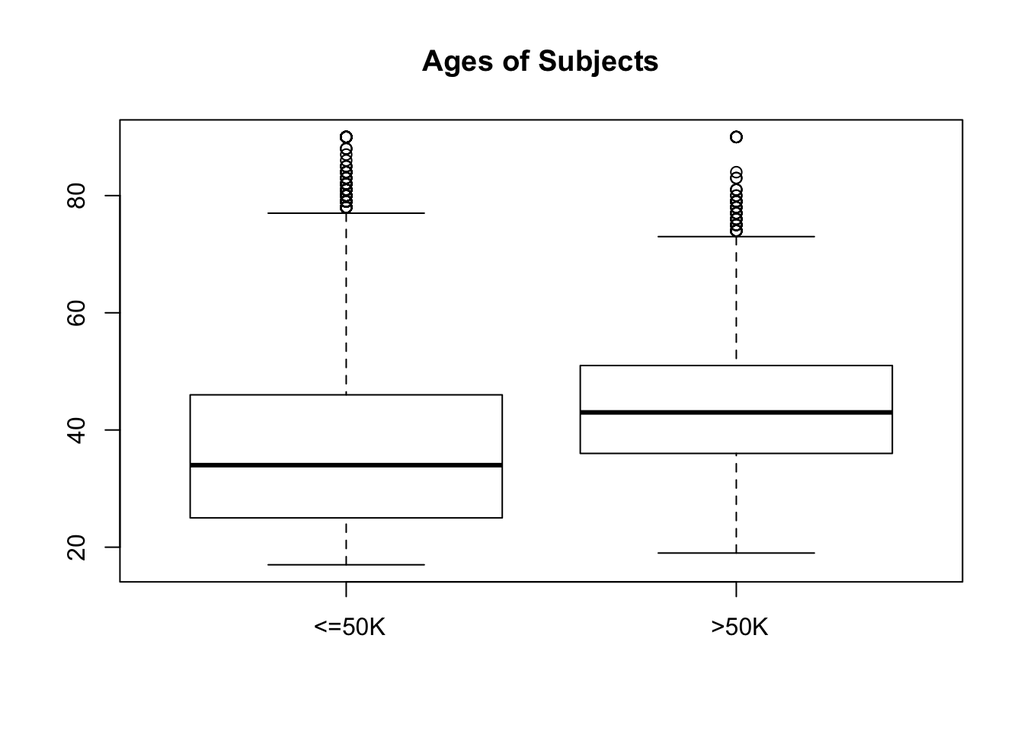

```r
boxplot(adultData$age ~ adultData$income_level, main="Ages of Subjects")
```

The box-and-whiskers plot depicts the five-number summary values using the horizontal lines and dots. The horizontal lines forming the box in the middle of each figure represent Q1, Q2, and Q3 while reading the plot from the bottom to the top. The median is denoted by the dark line in the center. The min and max are the “whiskers” extending up and down from the box; they can extend only a min or max of 1.5 times the IQR below Q1 or above Q3. Any values below or above this range are **outliers** and from the boxplots shown, there are a large number of them when it comes to age. As an example, if the **IQR** is 10 and Q1 = 50, Q3 = 125, then outliers would be found when any value is < 50 - (1.5 x 10) or > 125 + (1.5 x 10).

## Visualizing numeric variables - histograms

A histogram is another way to graphically depict the spread of a numeric variable. It is similar to a boxplot in a way that it divides the variable’s values into a predefined number of portions or **bins** that act as containers for values. Their similarities end there, however. On one hand, a boxplot requires that each of the four portions of the data must contain the same number of values, and widens or narrow the bins as needed. On the other hand, a histogram uses any number of bins of an identical width, but allows the bins to contain different number of values.

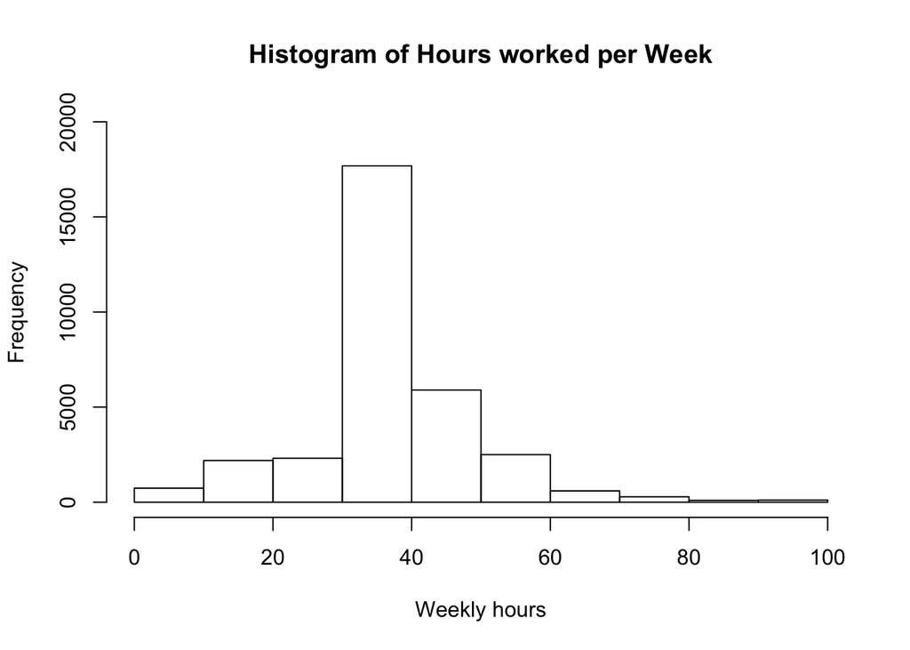

```r
hist(adultData$hours_per_week, main = "Histogram of Hours worked per Week", xlab = "Weekly hours", breaks = 10, ylim = c(0, 20000))
```

The histogram is composed of a series of bars with heights indicating the count, or **frequency** of values falling within each of the equal width bins partitioning the values. The vertical lines that separate the bars, as labeled on the horizontal axis, indicate the start and end points of the range of values for the bin. If you want to override the default bin size, use the *breaks* parameter with an integer like **breaks = 10** or **c(5000, 10000, 15000, 20000)**.

Now we look at Age to get a different perspective on histograms.

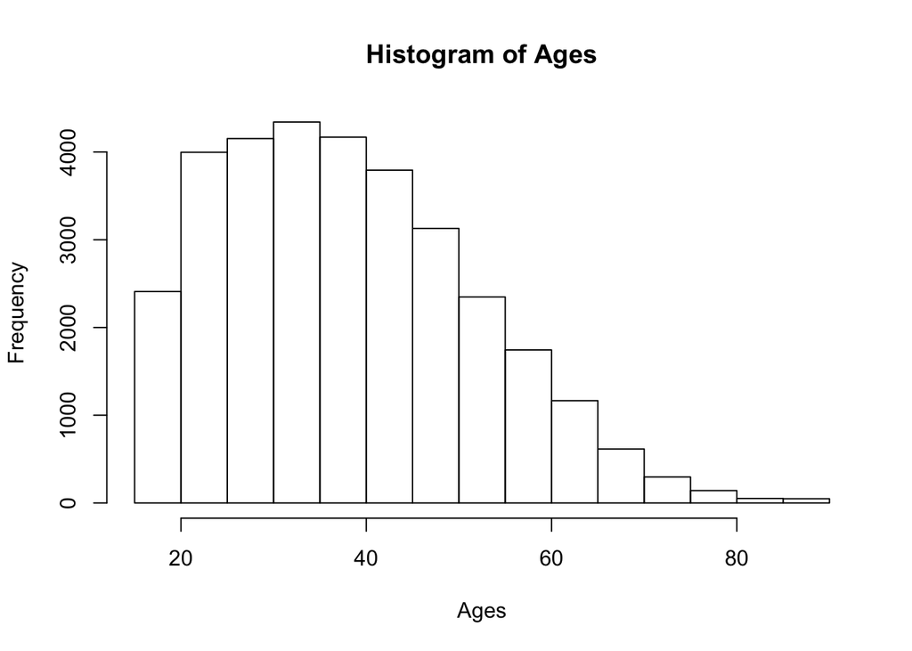

```r
hist(adultData$age, main = "Histogram of Ages", xlab = "Ages", breaks = 20)
```

This graphs shows that the majority of workers are in the age range of 20-45, and the frequencies drop off rapidly after 45.

Notice also that the shape of the two histograms is somewhat different. This is called **skew**, specifically, *right skew*, because the values on the high end (right side) are far more spread out than the values on the low end (left side). *Left skew* would be just the opposite.

## Understanding numeric data - uniform and normal distributions

A variable’s **distribution** describes how likely a value is to fall within various ranges. If all the values are equally likely to occur, the distribution is said to be **uniform**.

## Measuring spread - variance and standard deviation

Distributions allow us to characterize a large number of values using a smaller number of parameters; the *normal distribution* is described with just two parameters: **center**: mean and **spread**: standard deviation.

The **variance** is needed to calculate the **standard deviation** and it is the sum of the squared differences of each value and the mean divided by the number of values; the **stnadard deviation** is just the square root of the **variance**.

```r
mean(adultData$hours_per_week)
```

```
## [1] 40.39152
```

```r
var(adultData$hours_per_week)
```

```
## [1] 152.019
```

```r
sd(adultData$hours_per_week)
```

```
## [1] 12.3296
```

```r
mean(adultData$age)
```

```
## [1] 38.54348
```

```r
var(adultData$age)
```

```
## [1] 186.0969
```

```r
sd(adultData$age)
```

```
## [1] 13.64174
```

While interpreting the variance, larger numbers indicate that the data are spread more widely around the mean. The standard deviation indicates, on average, how much each value differs from the mean.

The standard deviation can be used to quickly estimate how extreme a given value is under the assumption that it came from a normal distribution. The **68-95-99.7 rule** states that *68%* of the values in a normal distribution fall withing one standard deviation of the mean, and so on. So, 3 standard deviations will contain 99.7% of the data.

In application, this means that if the mean = **x** and the standard deviation = **y**, 68% of the data lies between *x - y* and *x + y*. The basic principle applies to other distributions: values more than 3 stddevs from the mean are exceedingly rare.

# Exploring categorical variables

In contrast to *numeric* data, categorical data is typically examined using tables rather than summary statistics. A table that presents a single categorical variable is known as a **one-way table**. The _table()) function can be used to generate one-way tables.

```r
table(adultData$education)
```

```
##
##          10th          11th          12th       1st-4th       5th-6th
##           931          1175           433           168           333
##       7th-8th           9th    Assoc-acdm     Assoc-voc     Bachelors
##           646           513          1066          1381          5314
##     Doctorate       HS-grad       Masters     Preschool   Prof-school
##           401         10478          1705            51           530
##  Some-college
##          7277
```

```r
table(adultData$workclass)
```

```
##
##                 ?       Federal-gov         Local-gov      Never-worked
##              1832               959              2087                 7
##           Private      Self-emp-inc  Self-emp-not-inc         State-gov
##             22614              1080              2512              1297
##       Without-pay
##                14
```

```r
table(adultData$occupation)
```

```
##
##                  ?       Adm-clerical       Armed-Forces
##               1839               3764                  9
##       Craft-repair    Exec-managerial    Farming-fishing
##               4091               4024                994
##  Handlers-cleaners  Machine-op-inspct      Other-service
##               1369               2001               3293
##    Priv-house-serv     Prof-specialty    Protective-serv
##                149               4073                648
##              Sales       Tech-support   Transport-moving
##               3625                927               1596
```

The *table()* output lists the categories of the nominal variables and a count of the number of values falling into this category. You can use this information to determine proportions - knowing the number of observations, divide this into the particular category count. The R command *prop.table()* does this for you.

```r
round(prop.table(table(adultData$education)) * 100, digits = 1)
```

```
##
##          10th          11th          12th       1st-4th       5th-6th
##           2.9           3.6           1.3           0.5           1.0
##       7th-8th           9th    Assoc-acdm     Assoc-voc     Bachelors
##           2.0           1.6           3.3           4.3          16.4
##     Doctorate       HS-grad       Masters     Preschool   Prof-school
##           1.2          32.3           5.3           0.2           1.6
##  Some-college
##          22.5
```

```r
round(prop.table(table(adultData$workclass)) * 100, digits = 1)
```

```
##
##                 ?       Federal-gov         Local-gov      Never-worked
##               5.7               3.0               6.4               0.0
##           Private      Self-emp-inc  Self-emp-not-inc         State-gov
##              69.8               3.3               7.8               4.0
##       Without-pay
##               0.0
```

```r
round(prop.table(table(adultData$occupation)) * 100, digits = 1)
```

```
##
##                  ?       Adm-clerical       Armed-Forces
##                5.7               11.6                0.0
##       Craft-repair    Exec-managerial    Farming-fishing
##               12.6               12.4                3.1
##  Handlers-cleaners  Machine-op-inspct      Other-service
##                4.2                6.2               10.2
##    Priv-house-serv     Prof-specialty    Protective-serv
##                0.5               12.6                2.0
##              Sales       Tech-support   Transport-moving
##               11.2                2.9                4.9
```

## Measuring the central tendency - the mode

In statistics terms, the **mode** of a feature is the value occurring most often and is another measure of central tendency. It is most often used for categorical data, since the mean and median are not defined for nominal variables. A variable may have more than one mode; the types are **unimodal**, **bimodal**, and **multimodal**. The R *mode()* function is not what is used for determining the mode; rather, just look at the table output and find the category with the greatest count. Commonality is not majority - while a value may have the highest mode, one must look at the percentage relative to the overall set of observations.

# Exploring relationships between variables

So far, the analysis has been on **univariate** data only. There are other situaions, such as **bivariate** and **multivariate**.

## Visualizing relationships - scatterplots

A **scatterplot** is a digarm that visualizes a bivariate relationship, with *y* as the **dependent** variable and *x* as the **indepedent** variable.

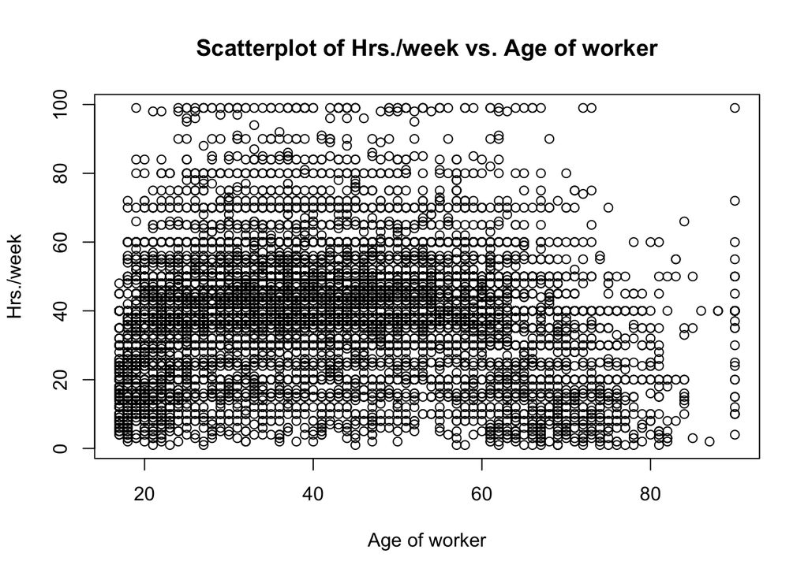

```r
plot(x = adultData$age,
     y = adultData$hours_per_week,
     main = "Scatterplot of Hrs./week vs. Age of worker",
     xlab = "Age of worker",
     ylab = "Hrs./week")
```

A negative association is a line going down, positive, a line going up, and, in this case, a flat line, or a seemingly random scattering of dots, implies no relationship at all. The strength of a linear association between two variables i measured by **correlation**. There can also be *non-linear* relationships between the variables, evidenced by V or U-shaped lines.

## Examining relationships - two-way cross-tabulations

To examine a relationship between two nominal (categorical) variables, a **two-way cross-tabluation** is used (also know as *crosstab* or *contingency table*). A cross-tabulation is similar to a scatterplot in that it allows you to examine how the values of one variable vary by the values of another. The format is a table in which the rows are the levels of one variable, while the columns are the levels of another. Counts in each of the table’s cells indicate the numer of values falling tinto the particular row and column combination. The *CrossTable()* option in the **gmodels** package shows the ros, column, and margin percentages in a single table. If there are many levels in the categorical variable under examination, it helps to reduce the number of levels through the use of a **dummy variable**; it can be used to divide the levels into more meaningful groups. The **%in%** operator is used for this task: it returns **TRUE** or **FALSE** for each value in the vector on the left side of the operator depending on whether the value is found in the vector on the right-hand side.

```r
adultData$highSchool <- adultData$education %in% c(" 9th", " 10th", " 11th", " 12th")
table(adultData$highSchool)
```

```
##
## FALSE  TRUE
## 29350  3052
```

This table shows that about 10% of the observations come from high-school age workers. We can see how occupation varies by high-school education level:

```r
library(gmodels)
CrossTable(x = adultData$occupation, y = adultData$highSchool)
```

```
##
##
##    Cell Contents
## |-------------------------|
## |                       N |
## | Chi-square contribution |
## |           N / Row Total |
## |           N / Col Total |
## |         N / Table Total |
## |-------------------------|
##
##
## Total Observations in Table:  32402
##
##
##                      | adultData$highSchool
## adultData$occupation |     FALSE |      TRUE | Row Total |
## ---------------------|-----------|-----------|-----------|
##                    ? |      1527 |       312 |      1839 |
##                      |    11.562 |   111.191 |           |
##                      |     0.830 |     0.170 |     0.057 |
##                      |     0.052 |     0.102 |           |
##                      |     0.047 |     0.010 |           |
## ---------------------|-----------|-----------|-----------|
##         Adm-clerical |      3607 |       157 |      3764 |
##                      |    11.445 |   110.062 |           |
##                      |     0.958 |     0.042 |     0.116 |
##                      |     0.123 |     0.051 |           |
##                      |     0.111 |     0.005 |           |
## ---------------------|-----------|-----------|-----------|
##         Armed-Forces |         8 |         1 |         9 |
##                      |     0.003 |     0.027 |           |
##                      |     0.889 |     0.111 |     0.000 |
##                      |     0.000 |     0.000 |           |
##                      |     0.000 |     0.000 |           |
## ---------------------|-----------|-----------|-----------|
##         Craft-repair |      3594 |       497 |      4091 |
##                      |     3.365 |    32.357 |           |
##                      |     0.879 |     0.121 |     0.126 |
##                      |     0.122 |     0.163 |           |
```

[output cut: 58 more lines]

```
##                      |     0.985 |     0.015 |     0.029 |
##                      |     0.031 |     0.005 |           |
##                      |     0.028 |     0.000 |           |
## ---------------------|-----------|-----------|-----------|
##     Transport-moving |      1346 |       250 |      1596 |
##                      |     6.872 |    66.082 |           |
##                      |     0.843 |     0.157 |     0.049 |
##                      |     0.046 |     0.082 |           |
##                      |     0.042 |     0.008 |           |
## ---------------------|-----------|-----------|-----------|
##         Column Total |     29350 |      3052 |     32402 |
##                      |     0.906 |     0.094 |           |
## ---------------------|-----------|-----------|-----------|
##
##
```

Each cell shows: